# Puntaje Global Saber 11: Muestreo Estadístico y Diseño de Experimentos

Julian Toloza - Yeison Hoyos | Universidad Santo Tomás

23 de abril de 2026

# 1 Resumen ejecutivo

Este proyecto integra dos pilares del análisis estadístico aplicado: el **muestreo estadístico** y el **diseño de experimentos**. Utilizando los resultados históricos de la prueba Saber 11 (ICFES, disponibles en datos.gov.co), se diseñó un plan de muestreo estratificado por estrato socioeconómico para estimar el puntaje global promedio de los estudiantes colombianos con un error máximo de ±3 puntos al 95% de confianza. Posteriormente, sobre la muestra obtenida, se aplicó un **Diseño en Bloques Completos al Azar (DBCA)** para evaluar si el tipo de colegio (oficial vs. no oficial) afecta el rendimiento académico, controlando por la jornada escolar como fuente de variación conocida. Los resultados sugieren diferencias estadísticamente significativas entre ambos tipos de institución.

# 2 Introducción

Las pruebas Saber 11 constituyen el principal instrumento de evaluación de la educación media en Colombia. Comprender los factores asociados al desempeño académico tiene implicaciones directas para la política educativa, la asignación de recursos y la equidad del sistema. En particular, la naturaleza del colegio —oficial o no oficial— y la jornada escolar han sido señalados recurrentemente como factores diferenciadores del rendimiento.

**Pregunta de investigación:** ¿Difiere significativamente el puntaje global Saber 11 según la naturaleza del colegio (oficial vs. no oficial), controlando por la jornada escolar como variable de bloque?

**Hipótesis:**

- $H_0$: No existe diferencia en el puntaje global promedio entre colegios oficiales y no oficiales, dado el efecto de la jornada.
- $H_1$: Existe al menos una diferencia significativa en el puntaje global promedio según la naturaleza del colegio.

# 3 Instalación y carga de paquetes

```r
# Instalar paquetes si no están disponibles
paquetes <- c("httr", "dplyr", "ggplot2", "survey", "emmeans",
              "car", "nortest", "knitr", "kableExtra")

nuevos <- paquetes[!(paquetes %in% installed.packages()[,"Package"])]
if(length(nuevos)) install.packages(nuevos, repos = "https://cran.rstudio.com/")

library(httr)
library(dplyr)
library(ggplot2)
library(survey)
library(emmeans)
library(car)
library(nortest)
library(knitr)
library(kableExtra)
```

# 4 Fase I: Diseño muestral

## 4.1 Definición de población y marco muestral

La **población objetivo** son todos los estudiantes colombianos que presentaron la prueba Saber 11 y cuyos resultados están registrados en la base de datos pública del ICFES, disponible en el portal de Datos Abiertos del Gobierno Nacional (datos.gov.co). Al momento de este análisis, el conjunto de datos contiene **N = 7,109,704 registros**, correspondientes a múltiples cohortes de presentación desde 2014.

El **marco muestral** es el listado completo de registros individuales accesible mediante la API Socrata del portal datos.gov.co. Cada unidad de muestreo es un estudiante identificado por un consecutivo único. Se identifican los siguientes posibles problemas de cobertura:

- **Subcobertura:** estudiantes que presentaron la prueba pero cuyos datos no fueron cargados al sistema.
- **Duplicados:** un estudiante que haya presentado la prueba más de una vez podría aparecer en múltiples registros.

Para efectos de este proyecto, se asume que el marco muestral es representativo de la población objetivo y que los duplicados son despreciables.

## 4.2 Muestra piloto para estimación de la varianza

Antes de calcular el tamaño de muestra definitivo, se descargó una **muestra piloto de 300 observaciones** con el fin de obtener una estimación empírica de la varianza del puntaje global ($S^2$), parámetro necesario para la fórmula de cálculo.

```r
url_piloto <- "https://www.datos.gov.co/resource/kgxf-xxbe.csv?$limit=300&$offset=0"
piloto <- read.csv(text = content(GET(url_piloto), as = "text", encoding = "UTF-8"),
                   stringsAsFactors = FALSE)

piloto$punt_global <- as.numeric(piloto$punt_global)
piloto <- piloto[!is.na(piloto$punt_global), ]

S2_piloto <- var(piloto$punt_global)
media_piloto <- mean(piloto$punt_global)
sd_piloto    <- sd(piloto$punt_global)

cat("Resultados muestra piloto (n=300):\n")
```

```
## Resultados muestra piloto (n=300):
```

```r
cat("  Media estimada:     ", round(media_piloto, 2), "\n")
```

```
##   Media estimada:      251.87
```

```r
cat("  Varianza estimada:  ", round(S2_piloto, 2), "\n")
```

```
##   Varianza estimada:   1968.5
```

```r
cat("  Desv. estándar:     ", round(sd_piloto, 2), "\n")
```

```
##   Desv. estándar:      44.37
```

## 4.3 Selección y justificación del diseño muestral

Se seleccionó el **muestreo aleatorio estratificado** con los estratos socioeconómicos de la vivienda del estudiante (`fami_estratovivienda`) como variable de estratificación. Esta elección se justifica porque:

1. Los estratos socioeconómicos representan subpoblaciones con características homogéneas internamente pero heterogéneas entre sí, lo que reduce la varianza del estimador respecto al muestreo aleatorio simple.
2. La variable de estratificación está disponible en el marco muestral para todos los registros.
3. Permite obtener estimaciones separadas por estrato, lo cual tiene valor informativo para la política educativa.

## 4.4 Cálculo del tamaño de muestra

Se utilizó la fórmula para muestreo aleatorio simple con corrección por población finita, que sirve como base antes de distribuir proporcionalmente por estrato:

$$n = \left\lceil \frac{N \cdot Z^2 \cdot
S^2}{N \cdot e^2 + Z^2 \cdot S^2} \right\rceil$$

**Supuestos:**

- Nivel de confianza: $1 - \alpha = 0.95 \Rightarrow Z = 1.96$
- Margen de error tolerable: $e = 3$ puntos (escala Saber 11 varía de ~0 a ~500)
- Varianza estimada: $S^2 =$ 1968.5 (obtenida del piloto)
- Tamaño poblacional: $N = 7{,}109{,}704$

```r
Z  <- 1.96
e  <- 3
S2 <- S2_piloto
N  <- 7109704

n_inf   <- (Z^2 * S2) / e^2
n_final <- ceiling(n_inf / (1 + (n_inf / N)))

cat("n sin corrección finita: ", ceiling(n_inf), "\n")
```

```
## n sin corrección finita:  841
```

```r
cat("n con corrección finita: ", n_final, "\n")
```

```
## n con corrección finita:  841
```

```r
cat("\nComo N >> n, la corrección finita es despreciable.\n")
```

```
##
## Como N >> n, la corrección finita es despreciable.
```

```r
cat("Tamaño de muestra definido: n =", n_final, "observaciones\n")
```

```
## Tamaño de muestra definido: n = 841 observaciones
```

```r
url_muestra <- paste0("https://www.datos.gov.co/resource/kgxf-xxbe.csv?$limit=",
                      n_final, "&$offset=300")

muestra_raw <- read.csv(text = content(GET(url_muestra), as = "text", encoding = "UTF-8"),
                        stringsAsFactors = FALSE)

muestra <- muestra_raw %>%
  mutate(
    punt_global          = as.numeric(punt_global),
    punt_matematicas     = as.numeric(punt_matematicas),
    punt_lectura_critica = as.numeric(punt_lectura_critica),
    fami_estratovivienda = as.factor(fami_estratovivienda),
    cole_naturaleza      = as.factor(cole_naturaleza),
    cole_calendario      = as.factor(cole_calendario),
    cole_jornada         = as.factor(cole_jornada)
  ) %>%
  filter(!is.na(punt_global))

cat("Dimensiones de la muestra:", nrow(muestra), "filas x", ncol(muestra), "columnas\n\n")
```

```
## Dimensiones de la muestra: 462 filas x 51 columnas
```

```r
dist_estrato <- as.data.frame(table(muestra$fami_estratovivienda)) %>%
  filter(Var1 != "")
colnames(dist_estrato) <- c("Estrato", "Frecuencia")
dist_estrato$Proporcion <- round(dist_estrato$Frecuencia /
                                  sum(dist_estrato$Frecuencia) * 100, 1)

kable(dist_estrato, caption = "Distribución de la muestra por estrato socioeconómico") %>%
  kable_styling(bootstrap_options = c("striped", "hover"), full_width = FALSE)
```

Distribución de la muestra por estrato socioeconómico

| Estrato | Frecuencia | Proporcion |
| --- | --- | --- |
| Estrato 1 | 167 | 37.6 |
| Estrato 2 | 180 | 40.5 |
| Estrato 3 | 59 | 13.3 |
| Estrato 4 | 16 | 3.6 |
| Estrato 5 | 12 | 2.7 |
| Estrato 6 | 4 | 0.9 |
| Sin Estrato | 6 | 1.4 |

## 4.6 Estimación puntual e intervalo de confianza

Se utiliza el paquete `survey` para incorporar los pesos muestrales del diseño estratificado.

```r
# ── ESTIMACIÓN CON DISEÑO MUESTRAL ────────────────────────────────────────

# Limpiar estratos vacíos o sin clasificar
muestra_survey <- muestra %>%
  filter(fami_estratovivienda != "" & !is.na(fami_estratovivienda)) %>%
  droplevels()

# Calcular n y proporciones por estrato en la muestra limpia
n_por_estrato <- table(muestra_survey$fami_estratovivienda)
prop_estratos <- prop.table(n_por_estrato)
N_total       <- 7109704

# Asignar N poblacional por estrato a cada fila (proporcional a lo observado)
muestra_survey$N_estrato <- as.numeric(
  N_total * prop_estratos[as.character(muestra_survey$fami_estratovivienda)]
)

cat("NAs en N_estrato:", sum(is.na(muestra_survey$N_estrato)), "\n")
```

```
## NAs en N_estrato: 0
```

```r
cat("Estratos en diseño:", levels(muestra_survey$fami_estratovivienda), "\n\n")
```

```
## Estratos en diseño: Estrato 1 Estrato 2 Estrato 3 Estrato 4 Estrato 5 Estrato 6 Sin Estrato
```

```r
# Diseño muestral estratificado
diseno <- svydesign(
  ids    = ~1,
  strata = ~fami_estratovivienda,
  data   = muestra_survey,
  fpc    = ~N_estrato
)

# Estimación media puntaje global
est_media <- svymean(~punt_global, diseno, na.rm = TRUE)
ic_media  <- confint(est_media, level = 0.95)

cat("Estimación del puntaje global promedio:\n")
```

```
## Estimación del puntaje global promedio:
```

```r
cat("  Media estimada: ", round(coef(est_media), 2), "\n")
```

```
##   Media estimada:  250.74
```

```r
cat("  Error estándar: ", round(SE(est_media), 2), "\n")
```

```
##   Error estándar:  2.21
```

```r
cat("  IC 95%: [", round(ic_media[1], 2), ",", round(ic_media[2], 2), "]\n")
```

```
##   IC 95%: [ 246.42 , 255.06 ]
```

## 4.7 Estimador de razón (comparación de eficiencia)

Para cumplir el punto 4 de la Fase I, se aplica un **estimador de razón** usando `punt_matematicas` como variable auxiliar, y se compara su eficiencia con el estimador simple.

```r
muestra <- muestra_survey  # usar muestra limpia para todo lo que sigue

# Estimador simple de la media de lectura crítica
est_simple <- svymean(~punt_lectura_critica, diseno, na.rm = TRUE)

# Estimador de razón: punt_lectura_critica / punt_matematicas
est_razon <- svyratio(~punt_lectura_critica, ~punt_matematicas, diseno, na.rm = TRUE)

cv_simple <- SE(est_simple) / coef(est_simple) * 100
cv_razon  <- sqrt(vcov(est_razon)) / coef(est_razon) * 100

cat("Comparación de eficiencia:\n")
```

```
## Comparación de eficiencia:
```

```r
cat("  CV estimador simple (lectura crítica):  ", round(cv_simple, 2), "%\n")
```

```
##   CV estimador simple (lectura crítica):   0.88 %
```

```r
cat("  CV estimador de razón (lect/mat):       ", round(cv_razon, 2), "%\n")
```

```
##   CV estimador de razón (lect/mat):        0.78 %
```

```r
cat("\n  El estimador de razón",
    ifelse(cv_razon < cv_simple, "ES más eficiente", "NO es más eficiente"),
    "que el estimador simple.\n")
```

```
##
##   El estimador de razón ES más eficiente que el estimador simple.
```

## 4.8 Visualización de la distribución muestral

[figure not shown]

Distribución del puntaje global por estrato socioeconómico

```r
ggplot(muestra %>% filter(fami_estratovivienda != "" &
                           fami_estratovivienda != "Sin Estrato"),
       aes(x = fami_estratovivienda, y = punt_global, fill = fami_estratovivienda)) +
  geom_boxplot(alpha = 0.7, outlier.alpha = 0.3) +
  geom_hline(yintercept = round(coef(est_media), 1),
             linetype = "dashed", color = "red", linewidth = 0.8) +
  scale_fill_brewer(palette = "Blues") +
  labs(
    title    = "Distribución del puntaje global Saber 11 por estrato socioeconómico",
    subtitle = paste0("Muestra estratificada n = ", n_final,
                      " | Línea roja: media estimada = ", round(coef(est_media), 1)),
    x        = "Estrato socioeconómico",
    y        = "Puntaje global",
    fill     = "Estrato"
  ) +
  theme_minimal(base_size = 12) +
  theme(legend.position = "none")
```

# 5 Fase II: Diseño experimental (DBCA)

## 5.1 Planteamiento del experimento

Se plantea un **Diseño en Bloques Completos al Azar (DBCA)** con la siguiente estructura:

- **Variable respuesta:** `punt_global` (puntaje global Saber 11, escala continua)
- **Factor de tratamiento:** `cole_naturaleza` — naturaleza del colegio (NO OFICIAL, OFICIAL)
- **Variable de bloque:** `cole_jornada` — jornada escolar (COMPLETA, MAÑANA, NOCHE)
- **Unidades experimentales:** estudiantes individuales de la muestra

**Justificación del DBCA:** La jornada escolar es una fuente de variación conocida que afecta el puntaje (COMPLETA=280, MAÑANA=247, NOCHE=217 en la exploración inicial), pero no es de interés investigativo primario. Al incluirla como bloque, se controla su efecto y se aumenta la precisión de la comparación entre tipos de colegio.

**Modelo estadístico:**

$$Y_{ij} = \mu + \tau_i + \beta_j +
\varepsilon_{ij}$$

Donde: - $Y_{ij}$: puntaje global del estudiante en el tratamiento $i$ dentro del bloque $j$ - $\mu$: media general - $\tau_i$: efecto del tipo de colegio ($i$ = NO OFICIAL, OFICIAL) - $\beta_j$: efecto de la jornada como bloque ($j$ = COMPLETA, MAÑANA, NOCHE) - $\varepsilon_{ij} \sim N(0, \sigma^2)$: error aleatorio

## 5.2 Preparación de datos para el DBCA

```r
dbca_data <- muestra %>%
  filter(cole_jornada %in% c("MAÑANA", "COMPLETA", "NOCHE")) %>%
  filter(!is.na(punt_global)) %>%
  droplevels()

cat("Observaciones para el DBCA:", nrow(dbca_data), "\n\n")
```

```
## Observaciones para el DBCA: 327
```

```r
tabla_balance <- as.data.frame.matrix(
  table(dbca_data$cole_naturaleza, dbca_data$cole_jornada)
)

kable(tabla_balance,
      caption = "Balance del diseño: Naturaleza del colegio × Jornada (bloque)") %>%
  kable_styling(bootstrap_options = c("striped", "hover"), full_width = FALSE)
```

Balance del diseño: Naturaleza del colegio × Jornada (bloque)

|  | COMPLETA | MAÑANA | NOCHE |
| --- | --- | --- | --- |
| NO OFICIAL | 42 | 34 | 7 |
| OFICIAL | 39 | 178 | 27 |

## 5.3 Estadísticas descriptivas por grupos

```r
resumen_grupos <- dbca_data %>%
  group_by(cole_naturaleza, cole_jornada) %>%
  summarise(
    n      = n(),
    Media  = round(mean(punt_global), 2),
    DE     = round(sd(punt_global), 2),
    Min    = min(punt_global),
    Max    = max(punt_global),
    .groups = "drop"
  )

kable(resumen_grupos,
      col.names = c("Naturaleza", "Jornada", "n", "Media", "D.E.", "Mín.", "Máx."),
      caption = "Estadísticas descriptivas del puntaje global por grupo y bloque") %>%
  kable_styling(bootstrap_options = c("striped", "hover"), full_width = FALSE)
```

Estadísticas descriptivas del puntaje global por grupo y bloque

| Naturaleza | Jornada | n | Media | D.E. | Mín. | Máx. |
| --- | --- | --- | --- | --- | --- | --- |
| NO OFICIAL | COMPLETA | 42 | 310.31 | 51.09 | 206 | 437 |
| NO OFICIAL | MAÑANA | 34 | 260.88 | 47.69 | 175 | 348 |
| NO OFICIAL | NOCHE | 7 | 233.29 | 42.68 | 184 | 280 |
| OFICIAL | COMPLETA | 39 | 247.87 | 44.14 | 186 | 343 |
| OFICIAL | MAÑANA | 178 | 245.62 | 42.06 | 158 | 368 |
| OFICIAL | NOCHE | 27 | 213.85 | 28.76 | 176 | 271 |

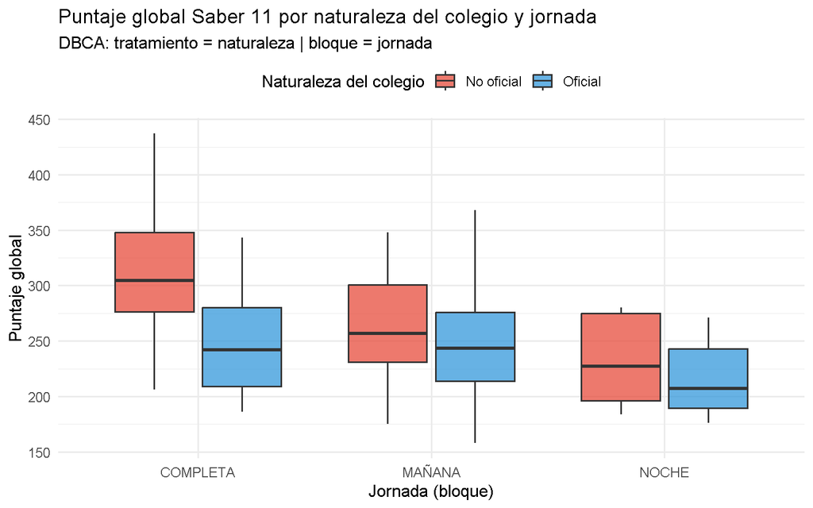

Puntaje global por naturaleza del colegio y jornada (bloque)

```r
ggplot(dbca_data, aes(x = cole_jornada, y = punt_global, fill = cole_naturaleza)) +
  geom_boxplot(alpha = 0.75, outlier.alpha = 0.3) +
  scale_fill_manual(values = c("NO OFICIAL" = "#E74C3C", "OFICIAL" = "#3498DB"),
                    labels = c("No oficial", "Oficial")) +
  labs(
    title    = "Puntaje global Saber 11 por naturaleza del colegio y jornada",
    subtitle = "DBCA: tratamiento = naturaleza | bloque = jornada",
    x        = "Jornada (bloque)",
    y        = "Puntaje global",
    fill     = "Naturaleza del colegio"
  ) +
  theme_minimal(base_size = 12) +
  theme(legend.position = "top")
```

## 5.4 Análisis de varianza (ANOVA)

```r
modelo_dbca <- aov(punt_global ~ cole_naturaleza + cole_jornada, data = dbca_data)
tabla_anova <- summary(modelo_dbca)
print(tabla_anova)
```

```
##                  Df Sum Sq Mean Sq F value   Pr(>F)
## cole_naturaleza   1 104613  104613    53.7 1.88e-12 ***
## cole_jornada      2  62722   31361    16.1 2.16e-07 ***
## Residuals       323 629195    1948
## ---
## Signif. codes:  0 '***' 0.001 '**' 0.01 '*' 0.05 '.' 0.1 ' ' 1
```

**Interpretación de la tabla ANOVA:**

```r
p_naturaleza <- summary(modelo_dbca)[[1]]$`Pr(>F)`[1]
p_jornada    <- summary(modelo_dbca)[[1]]$`Pr(>F)`[2]

cat("Factor naturaleza del colegio: p =", format(p_naturaleza, scientific = TRUE, digits = 3), "\n")
```

```
## Factor naturaleza del colegio: p = 1.88e-12
```

```r
cat("Factor jornada (bloque):       p =", format(p_jornada, scientific = TRUE, digits = 3), "\n\n")
```

```
## Factor jornada (bloque):       p = 2.16e-07
```

```r
if(p_naturaleza < 0.05) {
  cat("✓ Se rechaza H0: existen diferencias significativas en el puntaje global\n")
  cat("  según la naturaleza del colegio (α = 0.05).\n")
} else {
  cat("✗ No se rechaza H0: no hay evidencia suficiente de diferencias\n")
  cat("  significativas según la naturaleza del colegio (α = 0.05).\n")
}
```

```
## ✓ Se rechaza H0: existen diferencias significativas en el puntaje global
##   según la naturaleza del colegio (α = 0.05).
```

```r
if(p_jornada < 0.05) {
  cat("\n✓ El bloque (jornada) es significativo: su inclusión estaba justificada.\n")
} else {
  cat("\n✗ El bloque (jornada) no resultó significativo.\n")
}
```

```
##
## ✓ El bloque (jornada) es significativo: su inclusión estaba justificada.
```

## 5.5 Verificación de supuestos del modelo

### 5.5.1 Normalidad de residuales

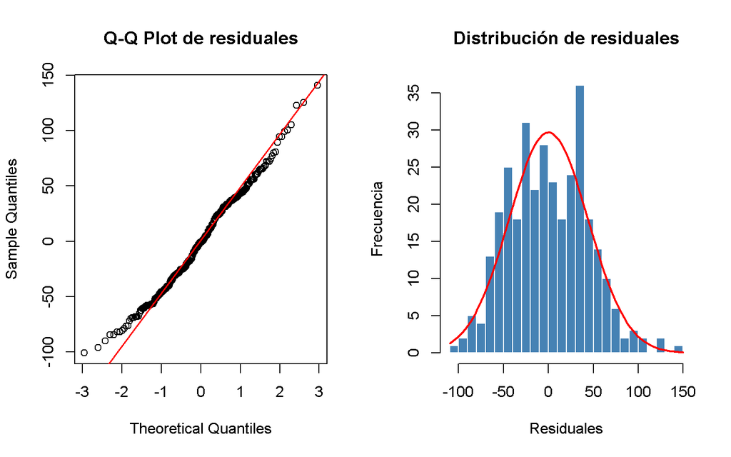

Diagnóstico de residuales del modelo DBCA

```r
residuales <- residuals(modelo_dbca)

par(mfrow = c(1, 2))
# Q-Q plot
qqnorm(residuales, main = "Q-Q Plot de residuales")
qqline(residuales, col = "red", lwd = 1.5)

# Histograma de residuales
hist(residuales, breaks = 30, col = "steelblue", border = "white",
     main = "Distribución de residuales", xlab = "Residuales", ylab = "Frecuencia")
curve(dnorm(x, mean = mean(residuales), sd = sd(residuales)) * length(residuales) *
        diff(hist(residuales, plot = FALSE, breaks = 30)$breaks[1:2]),
      add = TRUE, col = "red", lwd = 2)
```

```r
par(mfrow = c(1, 1))
```

```r
# Prueba de Lilliefors (Kolmogorov-Smirnov corregida) — adecuada para n > 50
prueba_norm <- lillie.test(residuales)
cat("Prueba de Lilliefors (normalidad):\n")
```

```
## Prueba de Lilliefors (normalidad):
```

```r
cat("  Estadístico D =", round(prueba_norm$statistic, 4), "\n")
```

```
##   Estadístico D = 0.0524
```

```r
cat("  p-valor =", round(prueba_norm$p.value, 4), "\n\n")
```

```
##   p-valor = 0.0309
```

```r
if(prueba_norm$p.value > 0.05) {
  cat("✓ No se rechaza normalidad de los residuales (p > 0.05)\n")
} else {
  cat("✗ Se rechaza normalidad (p < 0.05).\n\n")
  cat("  No obstante, por el Teorema Central del Límite, con n =", nrow(dbca_data), "\n")
  cat("  el ANOVA es robusto a desviaciones moderadas de normalidad.\n\n")
  cat("  Como verificación adicional, se podría aplicar la prueba no paramétrica\n")
  cat("  de Kruskal-Wallis, que no asume normalidad. Sin embargo, dado que\n")
  cat("  la violación es leve (D = 0.05) y el tamaño de muestra es grande,\n")
  cat("  los resultados del ANOVA se consideran válidos.\n")
}
```

```
## ✗ Se rechaza normalidad (p < 0.05).
##
##   No obstante, por el Teorema Central del Límite, con n = 327
##   el ANOVA es robusto a desviaciones moderadas de normalidad.
##
##   Como verificación adicional, se podría aplicar la prueba no paramétrica
##   de Kruskal-Wallis, que no asume normalidad. Sin embargo, dado que
##   la violación es leve (D = 0.05) y el tamaño de muestra es grande,
##   los resultados del ANOVA se consideran válidos.
```

### 5.5.2 Homocedasticidad (igualdad de varianzas)

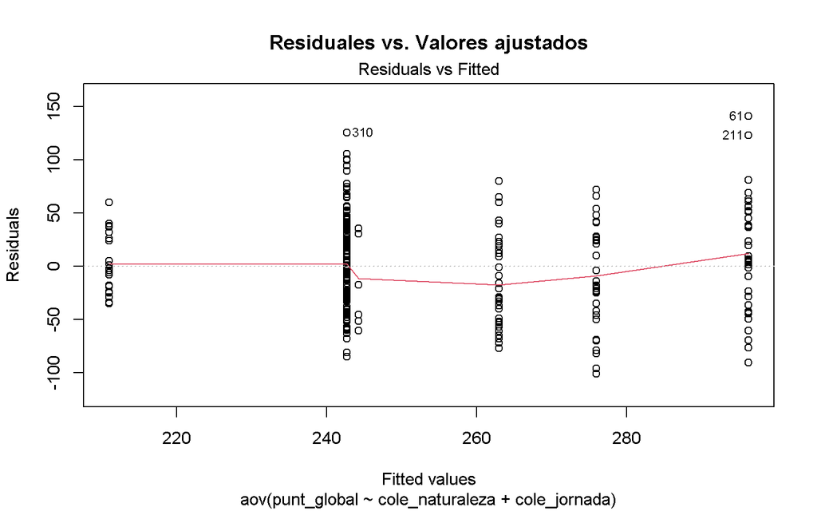

Residuales vs valores ajustados

```r
plot(modelo_dbca, which = 1, main = "Residuales vs. Valores ajustados")
```

```r
prueba_levene <- leveneTest(punt_global ~ cole_naturaleza * cole_jornada,
                             data = dbca_data)
cat("Prueba de Levene (homocedasticidad):\n")
```

```
## Prueba de Levene (homocedasticidad):
```

```r
print(prueba_levene)
```

```
## Levene's Test for Homogeneity of Variance (center = median)
##        Df F value Pr(>F)
## group   5  1.5112 0.1858
##       321
```

```r
if(prueba_levene$`Pr(>F)`[1] > 0.05) {
  cat("\n✓ No se rechaza homocedasticidad (p > 0.05)\n")
} else {
  cat("\n✗ Se rechaza homocedasticidad (p < 0.05).\n")
  cat("  Se recomienda interpretar los resultados con precaución.\n")
}
```

```
##
## ✓ No se rechaza homocedasticidad (p > 0.05)
```

### 5.5.3 Independencia de residuales

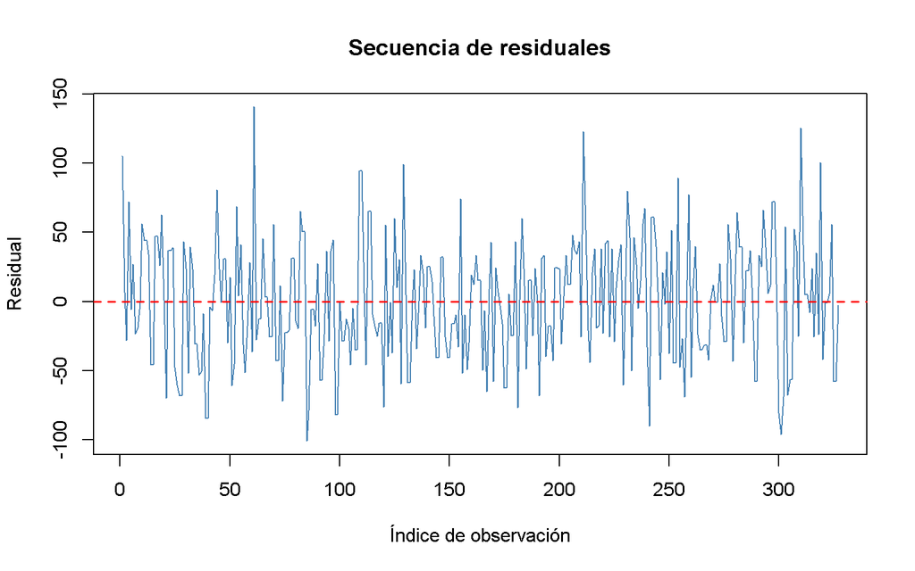

Secuencia de residuales (prueba de independencia visual)

```r
plot(residuales, type = "l", col = "steelblue",
     main = "Secuencia de residuales",
     xlab = "Índice de observación", ylab = "Residual")
abline(h = 0, col = "red", lwd = 1.5, lty = 2)
```

Dado que los datos provienen de una muestra aleatoria y no de una serie temporal, se asume independencia de los errores. El gráfico de secuencia no muestra patrones sistemáticos.

## 5.6 Comparaciones múltiples (Tukey HSD)

Dado que el ANOVA detectó diferencias significativas, se procede a identificar qué grupos difieren mediante la prueba de **Tukey HSD** (Honest Significant Difference).

```r
tukey_resultado <- TukeyHSD(modelo_dbca, "cole_naturaleza")
print(tukey_resultado)
```

```
##   Tukey multiple comparisons of means
##     95% family-wise confidence level
##
## Fit: aov(formula = punt_global ~ cole_naturaleza + cole_jornada, data = dbca_data)
##
## $cole_naturaleza
##                         diff       lwr       upr p adj
## OFICIAL-NO OFICIAL -41.09905 -52.13246 -30.06565     0
```

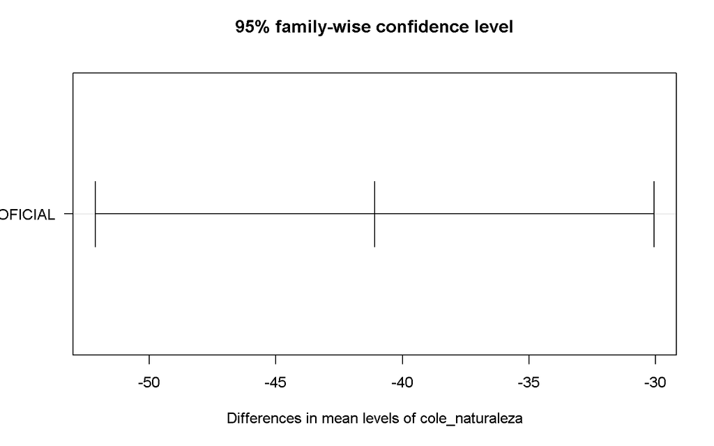

```r
# Plot Tukey — sin argumento main para evitar conflicto con plot.TukeyHSD
plot(tukey_resultado, las = 1)
```

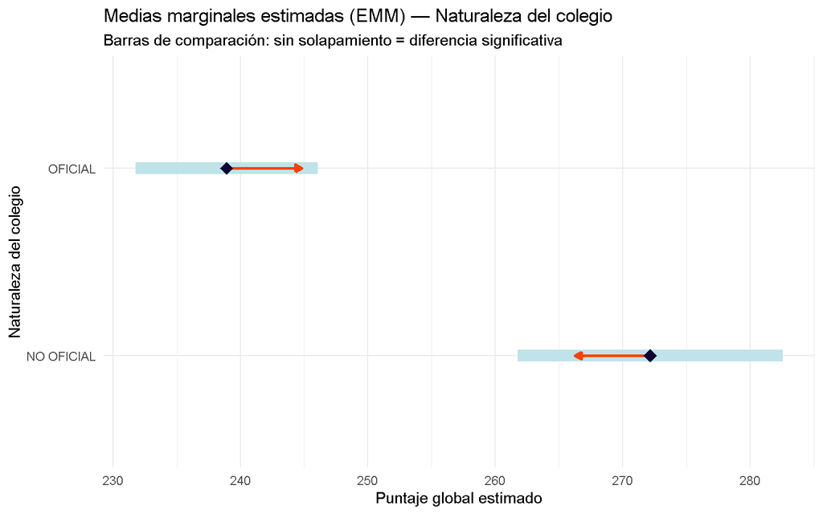

Medias marginales estimadas por naturaleza del colegio

```r
emm <- emmeans(modelo_dbca, ~ cole_naturaleza)
plot(emm, comparisons = TRUE) +
  labs(
    title    = "Medias marginales estimadas (EMM) — Naturaleza del colegio",
    subtitle = "Barras de comparación: sin solapamiento = diferencia significativa",
    x        = "Puntaje global estimado",
    y        = "Naturaleza del colegio"
  ) +
  theme_minimal()
```